# 🎓 **Homework #1. Dependencies management** 🎓

### 👤 **Assigner**:

**Malkova Ksenia**

### ✍️ **Contacts**:

- kemalkova@edu.hse.ru
- [@ksu_marshmallow](https://t.me/ksu_marshmallow)

### 🔥 **Deadline** 🔥:

- **04.12.2024**

# Part 1. Theory [2]

We will start with a few theoretical questions

**Question #1**

> What is conda? How it differs from apt, yarn, and others? Additionally, discuss the role of Mamba in the Conda ecosystem. How does Mamba improve upon Conda, and what are the potential benefits and drawbacks of using Mamba over Conda? [0.5]

**Answer #1**

**Conda** - менеджер пакетов и сред, который помогает устанавливать библиотеки, управлять зависимостями и создавать изолированные среды (virtual environment). Главное отличие от apt в том, что apt ставит пакеты глобально, делая их доступными всей ОС. Но если версии библиотек несовместимы или нужно использовать разные версии в разных проектах, то apt создаст огромную проблему из-за конфликта зависимостей. Конда же устанавливает все в изолированные среды, так что пакеты не мешают друг другу.

**Mamba** - почти то же самое, что и конда, только написанная на плюсах, поэтому чуть умнее и быстрее. Иногда может порешать зависимости, которые конда не может (либо может, но делает это очень долго)

**Mamba benefits**:

- C++
- Сильно экономит время и иногда спасает нервы, так как установка, обновления, решение зависимостей идут быстрее
- Если знаком с кондой, ничего нового запоминать не нужно..

**Mamba fails in**:

- Появилась только в 2019 году, поэтому сообщество еще не создалось - если с мамбой будет проблема, то тяжелее будет найти решение на просторах интернета

**Question #2**

> What is Docker, and how it differs from dependencies management systems? From virtual machines? [0.5]

**Answer #2**

**Docker** - инструмент для создания и упаковки приложений и их зависимостей в контейнеры, и последующего запуска в этих переносимых контейнерах. Докер-контейнеры уже включают все, что необходимо, для настройки и запуска приложения - код + зависимости + библиотеки и другие тулы. Они независимы от ОС хоста, поэтому их можно запускать с любой машины.

В отличие от менеджеров зависимостей (н-р, conda, mamba, pip), которые управляют библиотеками внутри одной среды, docker позволяет изолировать не только зависимости, но и само приложение вместе с его окружением. Это означает, что приложение, упакованное в контейнер, можно запускать на любом устройстве с установленным Docker, независимо от операционной системы или конфигурации машины хоста.

Докер-контейнеры работают немного похоже на виртуальные машины, но гораздо более специфичным и детализированным образом. VM "строят" полноценную ОС, включая ее ядро, что делает их тяжелыми (это дополнительная память, которая, к сожалению, не безгранична). Докер-контейнеры, с другой стороны, используют одну и ту же ОС хоста. Виртуализированы только среды выполнения с библиотеками и конфигурациями программ, а также приложения, включая их данные. Контейнерный движок действует как интерфейс между контейнерами и операционной системой хоста и выделяет необходимые ресурсы. Поэтому контейнер запускается быстрее виртуальной машины - нет необходимости загружать полную операционную систему.

**Question #3**

> What are the advantages and disadvantages of using containers over other approaches? [0.5]

**Answer #3**

**Плюсы контейнеров**

1. **Эффективность в использовании системных ресурсов** - образы контейнерных приложений потребляют гораздо меньше ресурсов хосты (вычислительная мощность, ОЗУ, дисковое пространство), чем VMs, быстрее запускаются и останавливаются, то есть их можно делать больше в пределах одного железа! Более того, контейнеры могут повторно используют компоненты благодаря образам. Здесь же вытекает, что это дешевле, поскольку для выполнения тех же рабочих нагрузок требуется гораздо меньше экземпляров ОС.
2. **Простое масштабирование** - контейнеры docker позволяют как просто масштабировать проект - как вертикально, изменяя размер вычислительных ресурсов на контейнер, так и горизонтально, добавив необзодимые контейнеры.
3. **Переносимость приложений** - контейнеры Docker инкапсулируют все, что нужно приложению для запуска (и только это), что позволяет легко перемещать приложения между средами. Любой хост с установленной средой выполнения Docker может запускать контейнер Docker
4. **Более безопасно чем ничего** - ПО в контейнере по умолчанию может быть более безопасным, чем ПО, работающее на обычном железе (так как изолирует все от ОС)
5. **Гибкость** - Docker позволяет использовать почти любой язык программирования и стек технологий на сервере, устраняя проблему несовместимости.
6. **Скорость развертывания** - создание контейнеров с помощью образов делает их готовыми к использованию за несколько секунд. Докер-контейнеры можно быстро обновлять (изменяя слой образа) или откатывать версию назад

**Минусы**

1. **Менее безопасно чем VM** - при атаке на хоста пострадают все контейнеры, которые используют общую ОС
2. **Может сойти с ума** - каждый контейнер потребляет ресурсы, и если не заботится об удалении всего лишнего (как внутри одного образа, так и про образы/контейнеры в целом), то докер может занять все ОЗУ
3. **Постоянное хранение данных** - завершение работы контейнера приведет к потере всех его данных, если только мы сначала не сохраним их где-то еще (есть Docker Data Volumes, но это уже на сложном)

**Question #4**

> Explain how Docker works: what are Dockerfiles, how are containers created, and how are they run and destroyed? [0.5]

**Answer #4**

1. **Dockerfile**. Dockerfile - это текстовый файл, в котором описаны шаги (инструкции и команды) для создания образа Docker. Каждая строка Dockerfile — это **слой образа**. В нем могут указываться:
   - Базовый образ (например, `python:3.9` или `ubuntu`)
   - Команды для установки зависимостей (`RUN apt install`, `COPY`, и т.д.)
   - Настройки окружения и переменные (`ENV`, `EXPOSE`)
   - Команда запуска приложения (`CMD` или `ENTRYPOINT`)
2. **Создание образа**. На основе Dockerfile создается **образ** с помощью команды `docker build`.
   - **Образ** — это шаблон для контейнеров, доступный только для чтения. Он хранит всю информацию о системе, нужной для запуска приложения: зависимости, файлы, системные утилиты
   - Используются для указания демону Docker требований к тому, как создавать контейнеры, и хранения всех метаданных, объясняющих возможности контейнера
   - Образы можно загружать с публичных реестров, таких как **Docker Hub**, или создавать свои. Если нужно или хочется, ими можно поделиться
   - Каждый образ состоит из нескольких **слоев** - инструкций из Dockerfile. Эти слои кэшируются (если не скажем не кэшировать), чтобы при повторной сборке не пересобирать неизмененные части. Если мы вносим изменения в инструкции предыдущего образа, то будет перестраиваться измененный слой и те, что находятся поверх него (а не строить ве с нуля). Слои в итоговом образе создают только инструкции **FROM**, **RUN**, **COPY**, **ADD**
3. **Создание и запуск контейнеров**. **Контейнер** — структурная и *изолированная* единица Docker, активный экземпляр образа. Именно контейнер хранит все необходимое для запуска приложения (код, фреймворки, библиотеки, бины). При запуске контейнера создается дополнительный слой для записи, поверх неизменяемого образа
   - Контейнер создается с помощью команды `docker run`
   - Контейнеры поддерживают **чтение и запись**, но изменения исчезают, если не сохранить их в новый образ (`docker commit`)
4. **Управление жизнью контейнеров**
   - **Остановка** - `docker stop` завершает работу контейнера, но данные в нем сохраняются
   - **Удаление** - `docker rm` удаляет контейнер полностью. Данные и приложения, связанные с этим контейнером, исчезают
   - Неиспользуемые контейнеры, образы и тома можно удалить командой `docker system prune`

# Part 2. Problem [6.25]

The problem itself is relatively simple.

Imagine that you developed an excellent RNA-seq analysis pipeline and want to share it with the world. Based on your experience, you are confident that the popularity of the pipeline will be proportional to its ease of use. So, you decided to help your future users and to pack all dependencies in a Conda environment and a Docker container.

Here is the list of tools and their versions that are used in your work:

- [fastqc](https://www.bioinformatics.babraham.ac.uk/projects/fastqc/), v0.11.9
- bcftools, v1.18
- samtools, v1.16.1
- [multiqc](https://github.com/ewels/MultiQC), v1.13

## Anaconda

### 1. Conda (mamba) installation [1]

Install conda (or mamba it will be better), create a new virtual environment, and install all necessary packages.

*You won't be able to install some tools - that's fine. List their names, and explain what should be done to make them conda-friendly ([conda-forge](https://conda-forge.org/docs/maintainer/adding_pkgs.html) channel, [bioconda](https://bioconda.github.io/contributor/workflow.html) channel).*

**Answer:**

У меня уже была установлена конда, но устанавливается она примерно так:

```
wget https://repo.anaconda.com/miniconda/Miniconda3-py310_22.11.1-1-Linux-x86_64.sh
    bash Miniconda3-py310_22.11.1-1-Linux-x86_64.sh
```

Мамбу я решила установить в бейзе, раньше ей не пользовалась. Для этого нужен канал conda-forge

```
conda config --add channels conda-forge
    conda install mamba -n base -c conda-forge
    mamba shell init
    source ~/.bashrc
```

У меня осталось только это, терминал подчищала :(

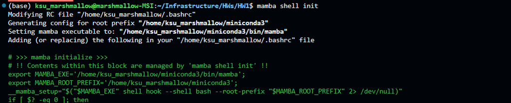

Создаем и активируем среду:

```
mamba create -n rnaseq_pipe
    mamba activate rnaseq_pipe
```

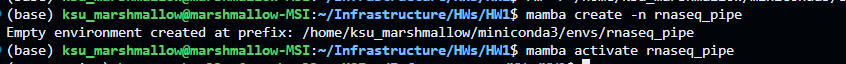

Добавляем каналы:

```
conda config --add channels anaconda
    conda config --add channels conda-forge
    conda config --add channels bioconda
```

И просто чекаем, что все установилось:

```
conda config --show channels
```

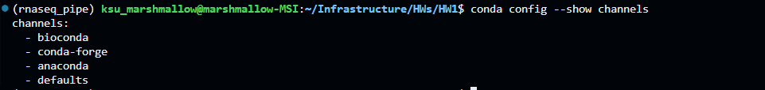

Устанавливаем все, что просили (хотя для этой дз только самтулс нужен)

```
mamba install fastqc=0.11.9 bcftools=1.18 samtools=1.16.1 multiqc=1.13
```

Ммм 154 пакета

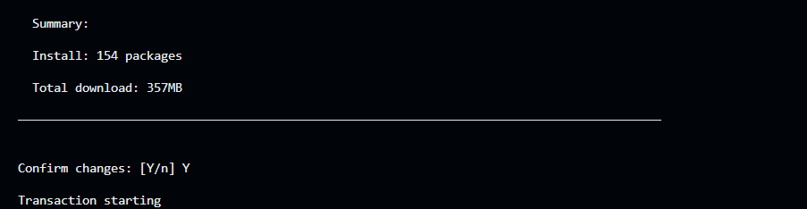

Ну и просто чекаем, что те версии установились

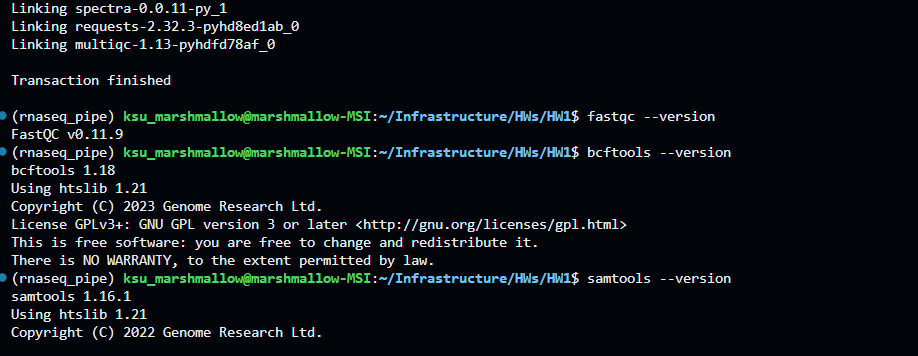

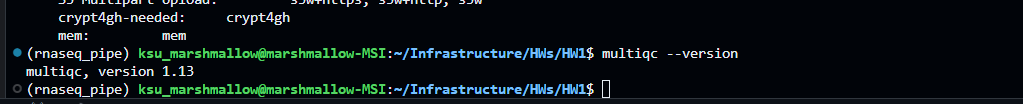

### 2. WGS data processing [0.5]

Download the full human genome (e.g., GRCh38 or hg19) and index it using samtools. Write a simple script (should be executable) using samtools and bedtools

**Answer:**

Взяла образец [HG00707](https://ftp.1000genomes.ebi.ac.uk/vol1/ftp/phase3/data/HG00707/) (1KGP phase 3)

#### Step 1. Create base script

Сначала просто создадим основу скрипта и сделаем его исполняемым.

Создаем скрипт:

```
vim pipeline.sh
```

В нем пишем это чудо (команда для проверки, что все работает):

```
#!/bin/bash

    echo $(whoami)
```

Делаем скрипт исполняемым:

```
chmod +x pipeline.sh
```

И собственно тестовый прогон:

```
./pipeline.sh
```

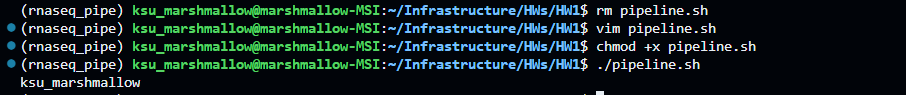

#### Step 2. Data loading

Здесь и далее (если не сказано иное) просто заполняем скрипт.

- Здесь я ввожу переменную `data_folder` - папочка, где буду лежать все файлы. Передается аргументом, но если не передается, то по умолчанию будет `data`. Также для отладки после скачивания проверяем содержимое папки `data_folder`.
- Флаг `-p` в `mkdir` нужен, чтобы не было ошибок, если директория уже существует
- Для отладки печатаем все директории в текущей. Флаг `-d` в `ls` означает перечисление директорий, а `*/` указывает, что мы хотим посмотреть директории только в текущей папке (где выполняется скрипт).

```
data_folder=${1:-data}
    mkdir -p "$data_folder"

    echo "Directories in the current directory: $(ls -d */)"
```

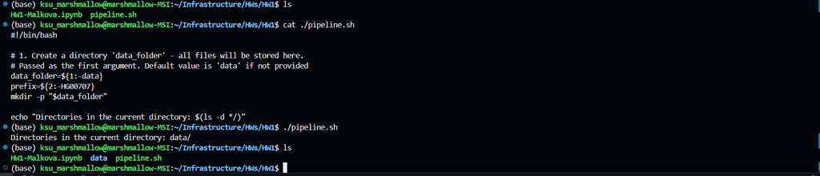

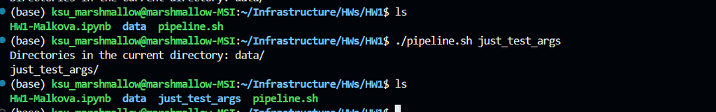

В скрипте пишем команду для установки `.bam` файла моего образца.

- Создаем второй аргумент `prefix` - по умолчанию по названию образца.
- Флаг `-O <path>` в `wget` - путь, куда устанавливать файл (папка + название файла)

```
prefix=${2:-HG00707}
   ...

   echo "Downloading the .bam file to the $data_folder directory..."
   wget -O "$data_folder/$prefix.bam" "https://ftp.1000genomes.ebi.ac.uk/vol1/ftp/phase3/data/HG00707/alignment/HG00707.mapped.ILLUMINA.bwa.CHS.low_coverage.20120522.bam"

   echo "Contents of $data_folder after downloading: $(ls $data_folder)"
```

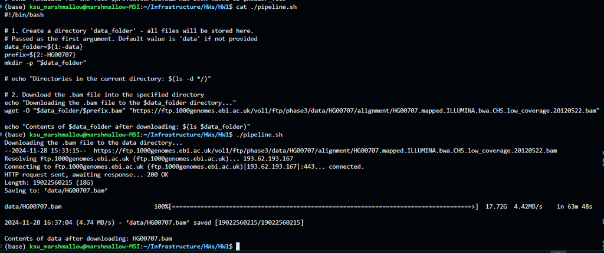

#### Step 3. `.bam` file processing

Индексируем и сортируем `.bam` файл (с помощью `samtools`).

```
echo "Indexing the .bam file..."
    samtools index "$data_folder/$prefix.bam"

    echo "Sorting the .bam file..."
    samtools sort "$data_folder/$prefix.bam" -o "$data_folder/$prefix.sorted.bam"

    echo "Remove initial .bam file..."
    rm "$data_folder/$prefix.bam"

    echo "Contents of $data_folder after indexing and sorting: $(ls $data_folder)"
```

У моего ноута психологическая травма

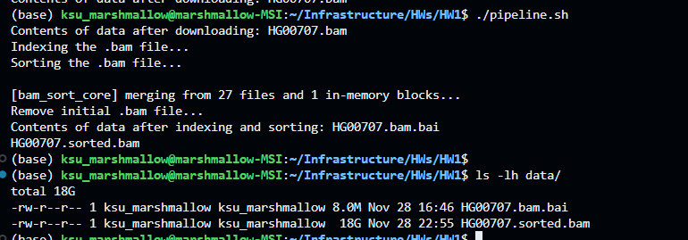

#### Step 4. Information extraction from `.bam` header

[SAM specification](https://samtools.github.io/hts-specs/SAMv1.pdf)

`bam` - бинарный `.sam` файл, содержит информацию о выравнивании ридов на геном. В заголовке (header) содержится вся метаинформация:

- Каждая новая строчка в header начинается с '@', за которой следует какой-то из двубуквенных **кодов** (`@HD`, `@SQ`, `@PG`, `@RG` etc)
- После кода tab-delimited следуют сколько-то тэгов с их значениями (пары `TAG:VALUE`). Звездочкой `*` отметила необходимые тэги
  - `@HD` (File-level metadata). Optional. If present, there must be only one @HD line and it must be the first line of the file:
    - `VN*` - версия SAM
    - `SO` - порядок сортировки (unknown, unsorted, queryname или coordinate)
  - `@SQ` (Reference sequence dictionary):
    - `SN*` - наименование референсного файла (на который выравнивали риды)
    - `LN*` - длина референсного файла
    - `AS` - сборка генома
    - `SP` - вид
    - `TP` - топология последовательности (linear, circular)
    - `UR` - URI последовательности
  - `@RG` (Read Group):
    - `ID*` - read group identifier
    - `PG` - programs used for processing the read group
    - `SM` - sample name
    - `PL` - платформа секвенирования (e.g. illumina, PacBio etc)
  - `@PG` (Programm):
    - `ID*` - program record identifier
    - `PN` - название программы (e.g. bwa, samtools etc)
    - `CL` - команда, в которой данная программа использовалась
    - `VN` - program version

Самая важная информация:

- **@HD SO** - знать, отсортирован ли файл и в каком порядке. Важно, например, при мерджинге `.bam` файлов (samtools merge ...) - все должны быть отсортированы одинаково. Также `macs`, `homer` и др. тулы работают только с сортировкой по координатам
- **@SQ AS** - сборка генома. Это самое важное, так как сборку нужно знать всегда и везде при пост-анализе. Например, если хотим вытащить только какие-то определенные участки (какой-то ген, или просто gene-encoding участки), то нужно будет это делать по геномным координатам нужных участков - а они в разных сборках разные.
- **@SQ SP** - вид, выравнивание ридов мы которого вообще смотрим. Мало ли хотели человека, а скачали собаку, всякое бывает
- **@RG PL** - платформа секвенирования. Чтобы знать, с чьими ридами работаем. Может быть важно при ???
- **@PG CL** - все команды, которые были использованы для получения данного файла. Мне кажется это важно в тех случаях, когда ты видишь странные результаты - можно проверить, какие команды и с какими флагами вызывались для получения этого `bam` файла.

Я решила зажестить (или может это ок), поэтому сделала следующее:

- Записываем заголовок в отдльную переменную, потом по нему будем грепаться. Это делаем с помощью самтулс (тэг `-H` помогает посмотреть только на заголовок в баме)

  ```
  header=$(samtools view -H "$data_folder/$prefix.sorted.bam")
  ```

- Для извлечения секции-тэга используем одни и те же команды, поэтому просто создадим массивы с секциями и тэгами (`sections` и `tags`), которые хотим извлекать. И пройдемся фором по этим массивам
- Для некоторых тэгов нам нужна только одна строчка (например, может быть несколько референсных файлов - и для каждого написана сборка и вид, хотя значение всегда одно), поэтому создали еще один массив по тэгам, для которых нам нужна только одна строчка (`tags_with_one_value`). Для них в дополнение к команде извлечения TAG:VALUE еще добавим `head -1`
- Так как не факт, что эти секции/тэги вообще есть в `.bam`, делаем условные конструкции при записи в файл (`if [[ -n $value ]]`)
- Основная команда для извлечения:

  ```
  value=$(echo "$header" | grep "^$section" | awk -v tag="$tag" '{for(i=1; i<=NF; i++) if ($i ~ tag":") print $i}'
  ```

  - `echo "$header"` - смотрим на заголовок, который сохранили в переменную
  - `grep "^$section"` - в этом заголовке ищем соответствующую секцию (@SQ и т.п.). Шапка нужна, так как с этого тэга должна начинаться строка (хотя так всегда, но ладно)
  - `awk -v tag="$tag" '{for(i=1; i<=NF; i++) if ($i ~ tag":") print $i}'`:
    - `-v` - делаем переменную tag внутри awk (вроде как обращаться к переменной, определенной внутри скрипта, внутри awk нельзя)
    - `for(i=1; i<=NF; i++)` - проходимся по всем полям в строке из section (от i до NF, где NF - общее количество полей в этой строке). По умолчанию поля разделяются пробелами или табами
    - `if ($i ~ tag":")` - проверяет, содержит ли текущее поле `$i` подстроку вида `TAG:`, если да - то выводим это поле (`print $i`) и сохраняем в переменную `value`
    - Для тэга `CL` еще переопределяем разделитель с помощью `-F'\t'` - заместо пробелов или табов говорим, что разделитель - тольк табы

```
header_file="$data_folder/HEADER_$prefix"
    echo "Extracting metadata from the .bam header into $header_file..."

    # Save the header to a variable
    header=$(samtools view -H "$data_folder/$prefix.sorted.bam")

    # Lists of sections and tags to extract
    sections=("@HD" "@SQ" "@SQ" "@RG" "@PG")
    tags=("SO" "AS" "SP" "PL" "CL")
    tags_with_one_value=("AS" "SP" "PL")
    descriptions=(
        "@HD SO tag (sort order)"
        "@SQ AS tag (assembly)"
        "@SQ SP tag (species)"
        "@RG PL tag (sequence platform)"
        "@PG CL tag (command line)"
    )

    # Search for tags - as not all tags might be present, we use conditional structures
    {
        echo "Metadata for the file $prefix.sorted.bam"
        echo "=================================="

        for i in "${!tags[@]}"; do
            tag="${tags[i]}"
            section="${sections[i]}"
            description="${descriptions[i]}"

            # For some tags, only the first value is needed; for CL, splitting by tabs is required
            if [[ "$tag" == "CL" ]]; then
                value=$(echo "$header" | grep "^$section" | awk -F'\t' -v tag="$tag" '{for(i=1; i<=NF; i++) if ($i ~ tag":") print $i}')
            elif [[ " ${tags_with_one_value[*]} " =~ " ${tag} " ]]; then
                value=$(echo "$header" | grep "^$section" | awk -v tag="$tag" '{for(i=1; i<=NF; i++) if ($i ~ tag":") print $i}' | head -1)
            else
                value=$(echo "$header" | grep "^$section" | awk -v tag="$tag" '{for(i=1; i<=NF; i++) if ($i ~ tag":") print $i}')
            fi

            # If the tag exists, write it to the file.
            if [[ -n $value ]]; then
                echo "$description"
                echo "$value"
                echo "-----------------------------------------------------------------------------"
            fi
        done
    } > "$header_file"

    echo "Metadata for the file $prefix.sorted.bam has been saved to $header_file"
```

Все предыдущие шаги закомментила (ту же боль сортировки не хотелось испытывать)

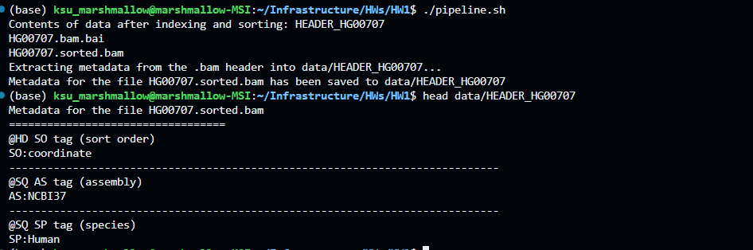

Как-то так это чудо выглядит:

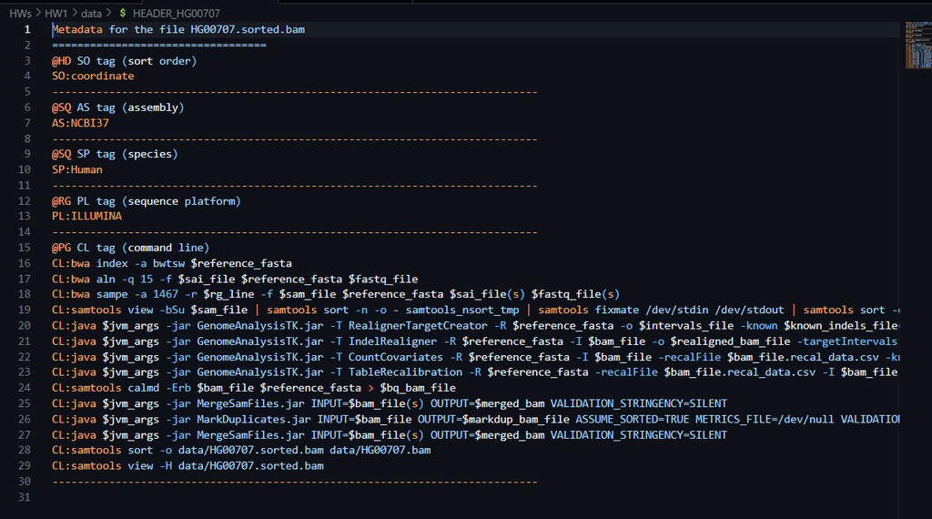

#### Step 5. Clear space

Я еще решила удалить все после вытаскивания заголовка, по крайней мере здесь эти файлы не нужны. А память на компе мне важна.

```
rm "$data_folder/$prefix.sorted.bam"
rm "$data_folder/$prefix.bam.bai"
echo "Sorted .bam file and index for it have been removed"
```

### 3. Environment file [0.25]

Export the environment to the file and verify that it can be rebuilt from the file without problems.

**Answer:**

Извлекаем все, что есть в среде в `.yaml`

```
mamba env export -n rnaseq_pipe --no-builds > environment.yaml
```

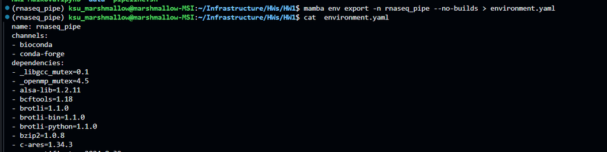

Проверяем, что все воспроизводится - отключаемся от среды и создаем новую

```
mamba deactivate
    mamba env create -n test_rnaseq_pipe -f environment.yaml
```

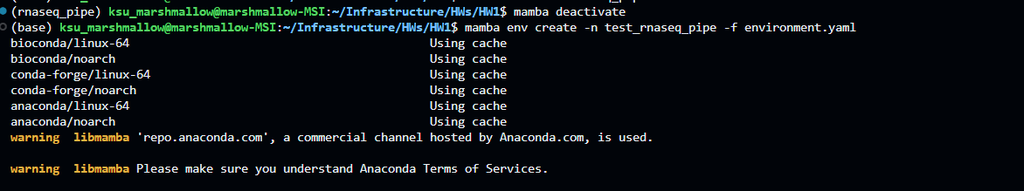

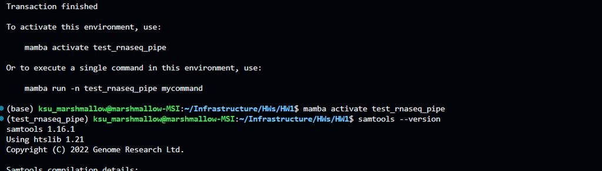

## Docker

### 1. Dockerfile [3.5]

Create a Dockerfile for a container with **all** required dependencies. Don't forget about comments; test that all tools are accessible and work inside the container. Repeat steps 1 -- 4 from Conda section, write a script for it. Hints:

- You are not allowed to use conda or conda image here.
- If needed, grant rights to execute downloaded/compiled binaries using chmod (`chmod a+x BINARY_NAME`)
- Move all executables to $PATH folders (e.g.`/usr/local/bin`) to make them accessible without specifying the full path.
- Typical command to run a container interactively and delete on exit.

#### 1.1 Install dependencies

Не знаю, нужно ли тут что-то объяснять, только кратко что для чего (большинство нужных зависимостей брала [отсюда](https://www.biostars.org/p/328831/)):

- `wget`, `make` и `unzip` - без комментариев
- `python3` и `python3-pip` - потому что multiqc устанавливаю через третью пипу
- `openjdk-17-jdk` - для джавы, которая нужна, чтобы поставить fastqc
- `libncurses5-dev` и `libncurses-dev` для библиотеки **ncurses** - нужно для samtools, bcftools и htslib
- `liblzma-dev`, `libbz2-dev`, `zlib1g-dev`, `libcurl4-openssl-dev` и `gcc` - тоже дл samtools, bcftools и htslib
- `perl` и `libfindbin-libs-perl` - тоже для fastqc

Ну и конечно же `rm -rf` в конце, чтобы не сохранять кэш (мы же хорошие)

```
FROM ubuntu:20.04

RUN echo "Setting up base image and installing dependencies..."

# Setting environment variables for non-interactive apt operations
ENV DEBIAN_FRONTEND=noninteractive
ENV PATH="/usr/local/bin:$PATH"

# Шnstall dependencies
RUN apt-get update && apt-get install -y \
    wget make unzip gcc openjdk-17-jdk libbz2-dev zlib1g-dev \
    liblzma-dev libcurl4-openssl-dev libncurses5-dev libncurses-dev \
    perl libfindbin-libs-perl \
    python3 python3-pip && \
    rm -rf /var/lib/apt/lists/*
```

#### 1.2 MultiQC installation

Это было самое простое, потому что можно установить пипом

```
# Set working directory
WORKDIR /usr/src

# Install MultiQC
RUN pip3 install --no-cache-dir multiqc==1.13
```

#### 1.3 HTSLIB

С того же [биостара](https://www.biostars.org/p/328831/) украла, как поставить htslib (и samtools и bcftools). Оставалось только выбрать нужную версию и добавить `rm -rf` в конце. Ну и добавить `make install`, чтобы сразу все в /usr/local/bin переносилось и тула была доступна глобально

```
RUN wget https://github.com/samtools/htslib/releases/download/1.21/htslib-1.21.tar.bz2 && \
    tar -xjf htslib-1.21.tar.bz2 && \
    cd htslib-1.21 && \
    make && \
    make install && \
    cd .. && rm -rf htslib-1.21*
```

#### 1.4 Samtools

Комментарии излишни (наверное?), то же самое, что и с htslib

```
RUN wget https://github.com/samtools/samtools/releases/download/1.16.1/samtools-1.16.1.tar.bz2 && \
    tar -xjf samtools-1.16.1.tar.bz2 && \
    cd samtools-1.16.1 && \
    make && \
    make install && \
    cd .. && rm -rf samtools-1.16.1*
```

#### 1.5 BCFTools

```
RUN wget https://github.com/samtools/bcftools/releases/download/1.18/bcftools-1.18.tar.bz2 && \
    tar -xjf bcftools-1.18.tar.bz2 && \
    cd bcftools-1.18 && \
    make && \
    make install && \
    cd .. && rm -rf bcftools-1.18*
```

Потом три тула объединила в один RUN (все скачиваются слава Богу одинаково, так как все из samtools):

```
RUN for tool in htslib-1.21 samtools-1.16.1 bcftools-1.18; do \
        wget -q https://github.com/samtools/${tool%%-*}/releases/download/${tool#*-}/$tool.tar.bz2 && \
        tar -xjf $tool.tar.bz2 && \
        cd $tool && \
        make && make install && \
        cd .. && rm -rf $tool*; \
    done
```

#### 1.6 FastQC

Поставить эту вещь без конды оказалось тяжелее

- Создаем временную папку, куда загрузим .zip
- Распаковываем в /usr/local (чтобы в основной папке /usr/src не мешалась)
- Делаем скрипт исполняемым и линкуем его в /usr/local/bin, чтобы был доступен из любого места
- Удаляем скачанный зип

По правде говоря, я такое скачивание у кого-то на докерхабе нашла, но ссыль потеряла на него :(

```
# Install FastQC
RUN wget http://www.bioinformatics.babraham.ac.uk/projects/fastqc/fastqc_v0.11.5.zip -O /tmp/fastqc.zip && \
    unzip /tmp/fastqc.zip -d /usr/local/ && \
    chmod a+x /usr/local/FastQC/fastqc && \
    ln -s /usr/local/FastQC/fastqc /usr/local/bin/fastqc && \
    rm /tmp/fastqc.zip
```

#### 1.7 Check installations

Чекаем, что все работает (из /usr/src)

```
RUN samtools --version && \
    bcftools --version && \
    fastqc --version && \
    multiqc --version && \
    echo "All tools installed"
```

#### 1.8 Add pipeline

Копируем наш скрипт, делаем исполняемым и запускаем :)

```
# Copy pipeline script and grant execution permissions
COPY pipeline.sh .
RUN chmod a+x pipeline.sh

# Set the default command
CMD ["./pipeline.sh"]
```

### 2. Eliminate warnings [1]

Use [hadolint](https://hadolint.github.io/hadolint/) and remove as many reported warnings as possible.

> Pin versions in apt get install. Instead of `apt-get install <package>` use `apt-get install <package>=<version>` Avoid additional packages by specifying `--no-install-recommends`

Добавила --no-install-recommends и версию 3.8 питона

```
RUN apt-get update && apt-get install -y --no-install-recommends \
    wget make unzip gcc openjdk-17-jdk libbz2-dev zlib1g-dev \
    liblzma-dev libcurl4-openssl-dev libncurses5-dev libncurses-dev \
    perl libfindbin-libs-perl \
    python3=3.8.* python3-pip && \
    rm -rf /var/lib/apt/lists/*
```

### 3. Additional info [0.5]

Add relevant [labels](https://docs.docker.com/engine/reference/builder/#label), e.g. maintainer, version, etc. ([hint](https://medium.com/@chamilad/lets-make-your-docker-image-better-than-90-of-existing-ones-8b1e5de950d))

```
ARG BUILD_DATE
LABEL maintainer="ksu_marshmallow" \
      org.label-schema.build-date=$BUILD_DATE \
      org.label-schema.name="BAM Processing Pipeline Image" \
      org.label-schema.description="Docker image for BAM file processing with Samtools" \
      org.label-schema.vcs-ref="main" \
      org.label-schema.schema-version="1.0"
```

### Run

1. **Билд зе имаге**

   ```
   docker build --build-arg BUILD_DATE=$(date -u +"%Y-%m-%dT%H:%M:%SZ") --progress=plain --no-cache --network=host -t rnaseq_pipe:v1 . > build.log 2>&1
   ```

Мне это нужно для отслеживания warnings, потому что консоль загрязняется и до них не долистать

- `--no-cache` - не сохраняет промежуточные слои
- `2>&1` - перенаправляет стандартный поток ошибок в стандартный поток вывода
- `--network=host` - без него у меня все ставилось по несколько часов. И очень печально, что я узнала о том, что это из-за проблем с их сетями, через пять суток)

Вот столько строк засоряло консоль

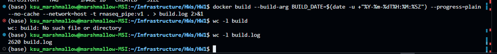

Чуть посмотрим на логи:

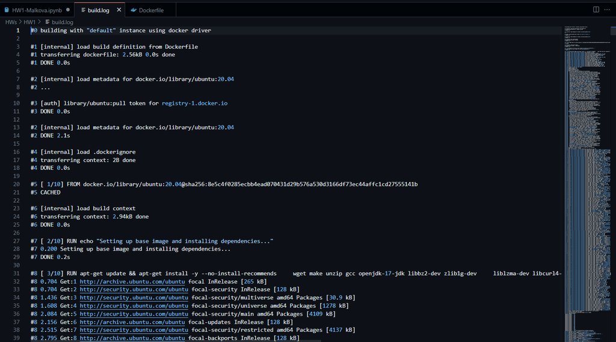

Вот это он решил доустановить:

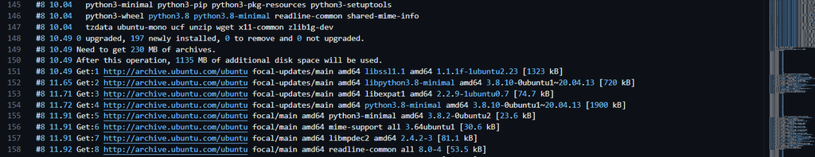

Вот такие ворнинги вылезали (один):

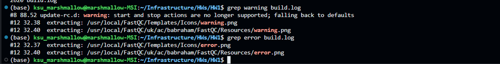

**Размер образа**

- **1.11 Gb**

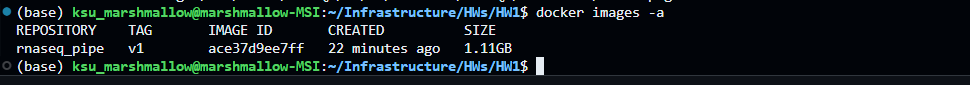

2. **Запуск контейнера**

```
docker run -dit --name rnaseq_pipe --network=host rnaseq_pipe:v1
```

- `--name` - имя контейнера
- `--network=host` - скачивание .bam работает только с хостовской сетью, иначе .bam будеть качаться гугол часов)
- `rnaseq_pipe:v1` - название образа
- `-d` - detach mode, запускают контейнер в фоновом режиме
- `-it` - отавляют контейнер интерактивным с подключением терминала
- `--rm` - можно поставить, он удаляет контейнер после того, как он отработал

Если запускать с флагом `-d`, то после запуска контейнера можно подключиться к его сессии:

```
docker exec -it rnaseq_pipe /bin/bash
```

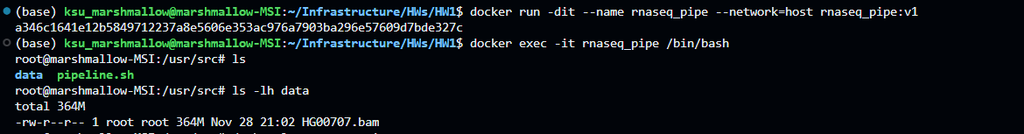

Можно нужно увидеть вывод скрипта pipeline.sh:

```
docker logs rnaseq_pipe
```

Здесь лаптоп проходит вторую войну и снова начинает сортировку (скорость печатания стала 1 буква в минуту):

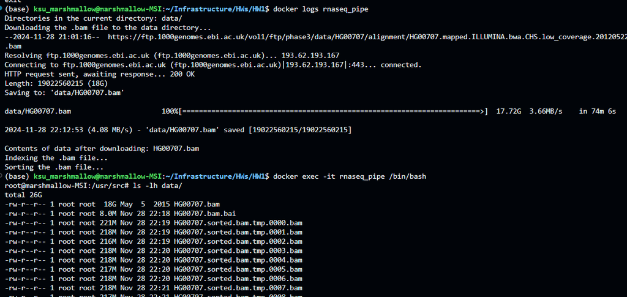

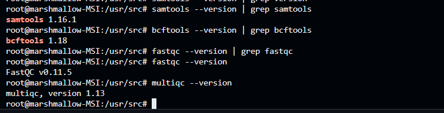

Оно завершилось!!

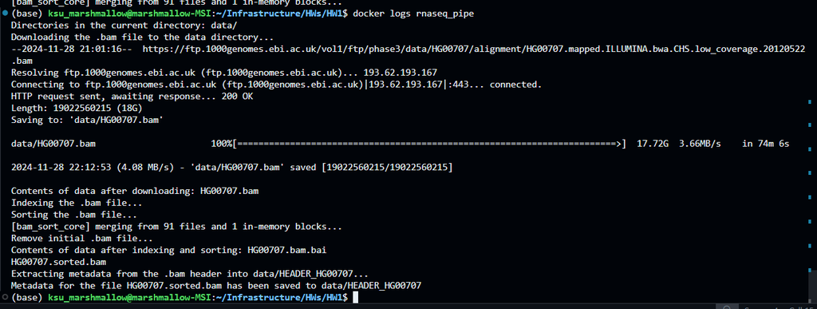

И контейнер сохранился, но в скрытых (простите за лишнее):

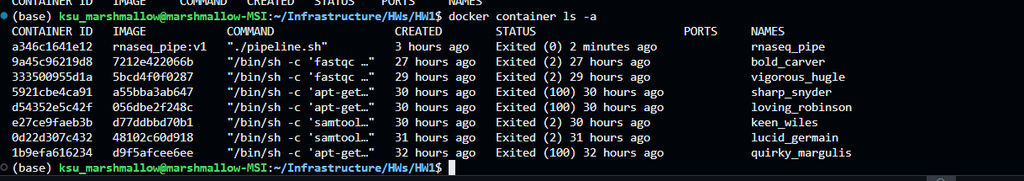

# Part 3. Extra points [1.75]

## Save your machine [1.25]

Minimize the size of the final Docker image. That is, removing all intermediates, unnecessary binaries/caches, etc. Don't forget to compare & report the final size before and after all the optimizations.

`--no-install-recommends` и `rm rf /var/lib/apt/lists/*` после apt-install у меня уже были. Из того, что еще можно сделать - удалить какие-то зависимости после установки тулов. Я добавила это

```
RUN apt-get purge -y gcc make unzip && apt-get autoremove -y && apt-get clean && rm -rf /var/lib/apt/lists/*
```

Потому что без чего-то другого все валится. Но ничего в размере не изменилось, хотя и удалилось:

[figure not shown]

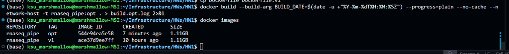

Ну в общем я не знаю, что еще придумать, поэтому посмотрю на размер, который был бы без `rm -rf` и `no-install recommends`, и у multiqc уберу --no-cache:

```
RUN apt-get update && apt-get install -y ...
WORKDIR /usr/src
RUN pip3 install multiqc==1.13
RUN for tool in htslib-1.21 samtools-1.16.1 bcftools-1.18; do \
        wget -q https://github.com/samtools/${tool%%-*}/releases/download/${tool#*-}/$tool.tar.bz2 && \
        tar -xjf $tool.tar.bz2 && \
        cd $tool && \
        make && make install && \
        cd ..; \
    done

RUN wget http://www.bioinformatics.babraham.ac.uk/projects/fastqc/fastqc_v0.11.5.zip -O /tmp/fastqc.zip && \
    unzip /tmp/fastqc.zip -d /usr/local/ && \
    chmod a+x /usr/local/FastQC/fastqc && \
    ln -s /usr/local/FastQC/fastqc /usr/local/bin/fastqc
```

Получилось так:

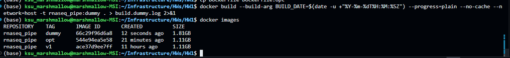

Возможно можно сказать, что мы сократили, просто изначально сделав все удаления и очистки кэша :)

## Extra Dockerfile [0.4]

Create an extra Dockerfile that starts from [a conda base image](https://hub.docker.com/r/continuumio/anaconda3) and builds everything from your conda environment file.

Hint: `conda env create --quiet -f environment.yml && conda clean -a` ([example](https://github.com/nf-core/clipseq/blob/master/Dockerfile))

**Answer:**

```
# что сказали, то и поставили
FROM continuumio/anaconda3:latest

# можно я не буду перечислять, чтобы не захламлять
LABEL ...
ENV DEBIAN_FRONTEND=noninteractive

# Нам нужен wget
RUN apt-get update && \
    apt-get install -y --no-install-recommends wget \
     && rm -rf /var/lib/apt/lists/*

WORKDIR /usr/src

# Install the conda environment
COPY environment.yaml .
RUN conda env create --quiet -f environment.yaml && conda clean -a

# Add conda installation dir to PATH (instead of doing 'conda activate')
ENV PATH /opt/conda/envs/rnaseq_pipe/bin:$PATH

# check yrself
RUN echo "Activating the conda environment and checking tool versions..." && \
    bash -c "source activate rnaseq_pipe && samtools --version && bcftools --version && fastqc --version && multiqc --version && echo 'All tools installed'"

# Copy pipeline script
COPY pipeline.sh .
RUN chmod +x pipeline.sh

# Default command
CMD ["./pipeline.sh"]
```

Делаем:

```
docker build --build-arg BUILD_DATE=$(date -u +"%Y-%m-%dT%H:%M:%SZ") --progress=plain --no-cache --network=host -t rnaseq_pipe:conda -f Dockerfile.conda . > build.conda.log 2>&1
```

В общем, я изначально запустила с тэгом v1, поэтому прошлый v1 стал none, но все равно эти образы больше не нужны

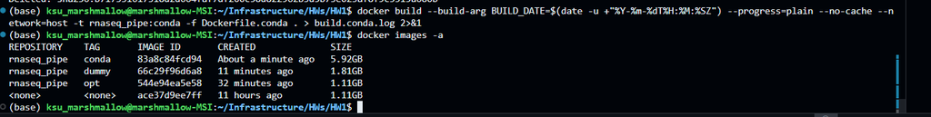

Занимает памяти конечно кхм немало

## Main part [0.1]

Share a meme about Docker or your impression of this assignment

[figure not shown]